# TCC - Curso R: Ciência de Dados I

### Proposta: Investimento na produção de um filme

Considerando o banco de dados *imdb*, o qual contém os dados de alguns filmes nos últimos anos, foi realizada uma análise para ver as caracteristicas dos filmes que obtiveram maior lucro e maior nota.

#### Primeiramente foram cosniderados os diretores:

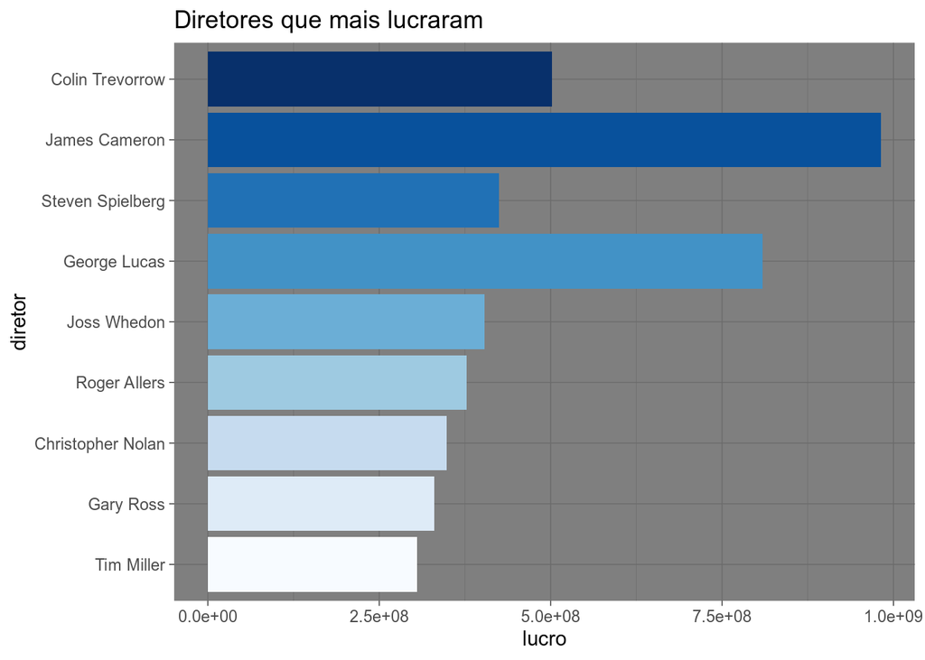

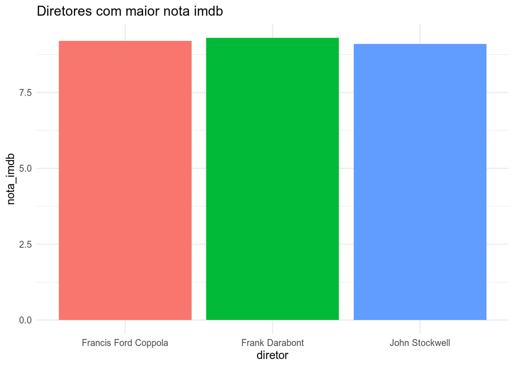

Pode-se observar que considerando o *lucro* os melhores diretores a se contratar seriam James Cameron e George Lucas. Entretanto, considerando a nota_imdb, os melhores diretores seriam Frank Darabont, Francis Ford Coppola e John Stockwell.

#### Em uma segunda análise foi considerado o gênero dos filmes:

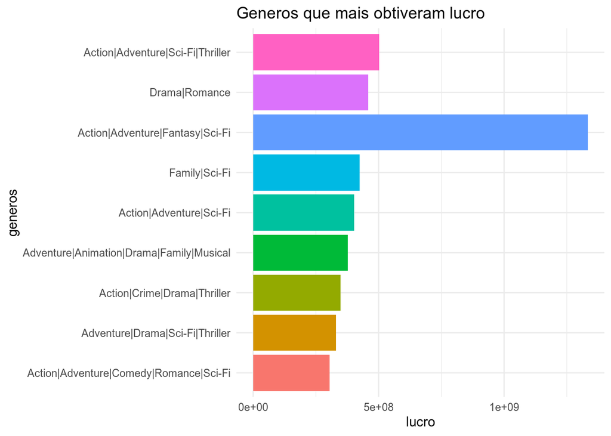

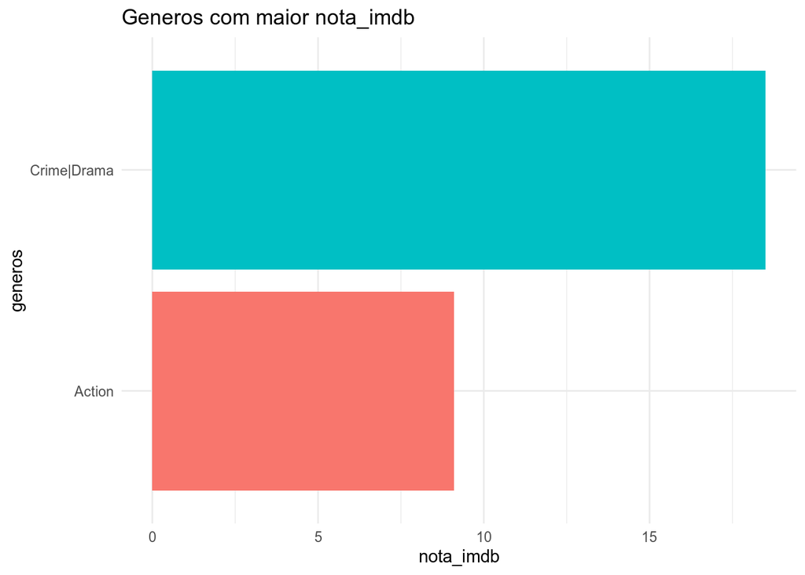

Os filmes classificados como de ação,aventura,fantasia e ficçao cientifica obtiveram maior lucro, enquanto que os filmes de crime/drama e ação apresentaram uma maior nota imdb.

#### Levando em consideração os atores, também foi realizada uma análise quanto ao lucro e quanto a nota_imdb:

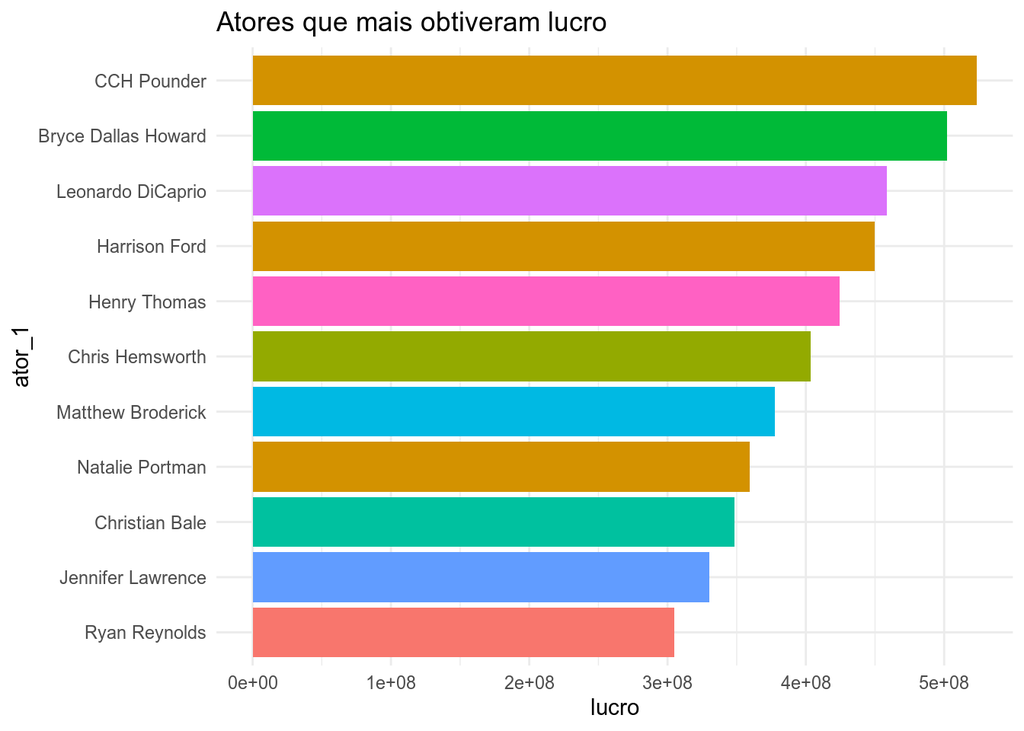

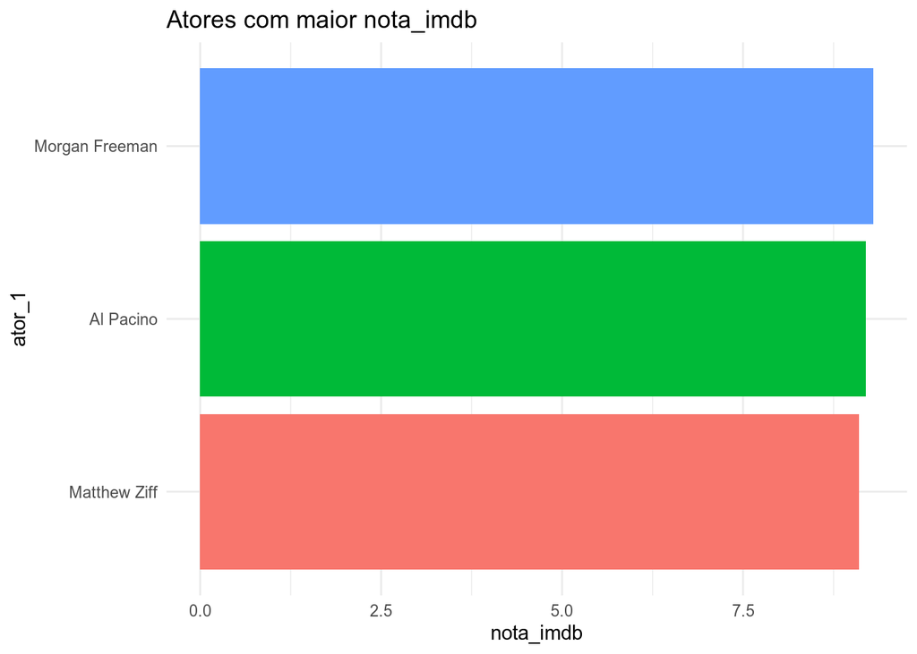

Os filmes que mais lucraram foram os que tem como atores principais: CCH Pounder, Bryce Dallas Howard, Leonardo Dicaprio e Harrison Ford, seguido de outros como mostra o gráfico acima. Já as melhores notas, são dos filmes que apresentam os atores Morgan Freeman, Al Pacino e Mathew Ziff.

#### Duração do filme

Os gráficos abaixo mostram a relação do lucro/nota_imdb com a duração do filme:

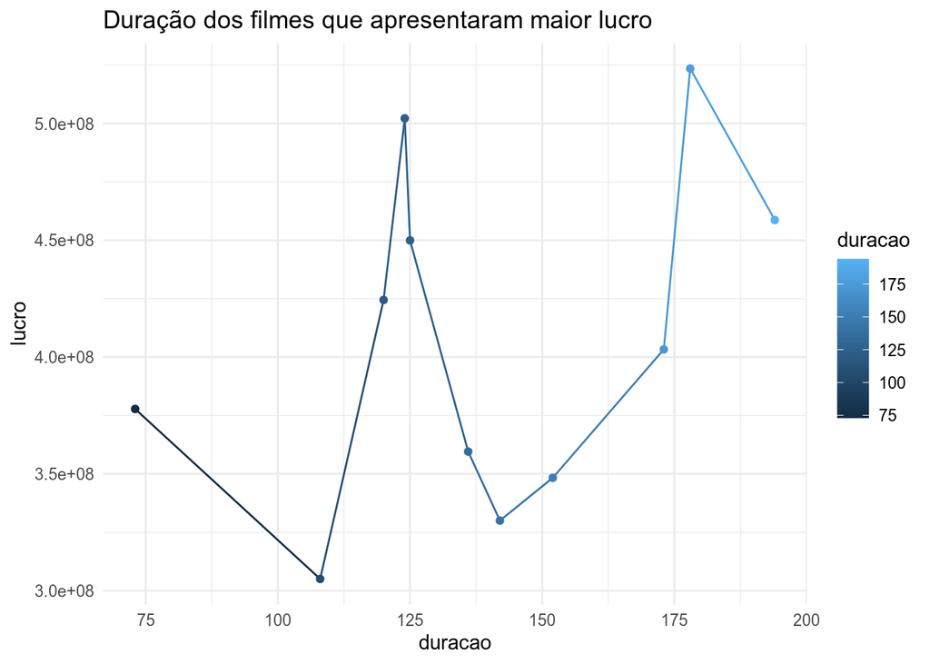

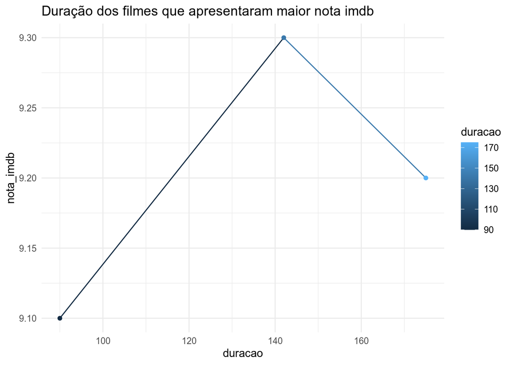

#### Classificação etária

Por último levou-se consideração para a análise, a classificação etária dos filmes.

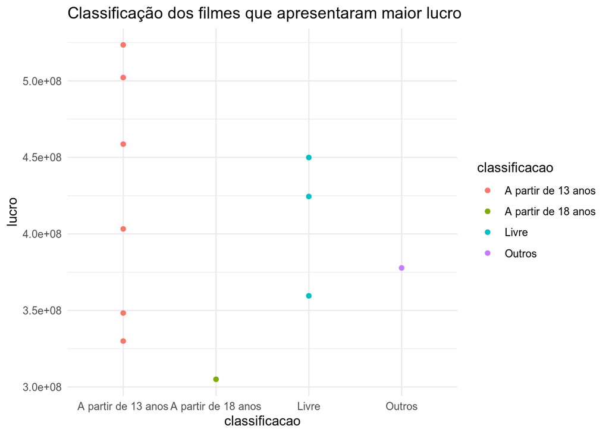

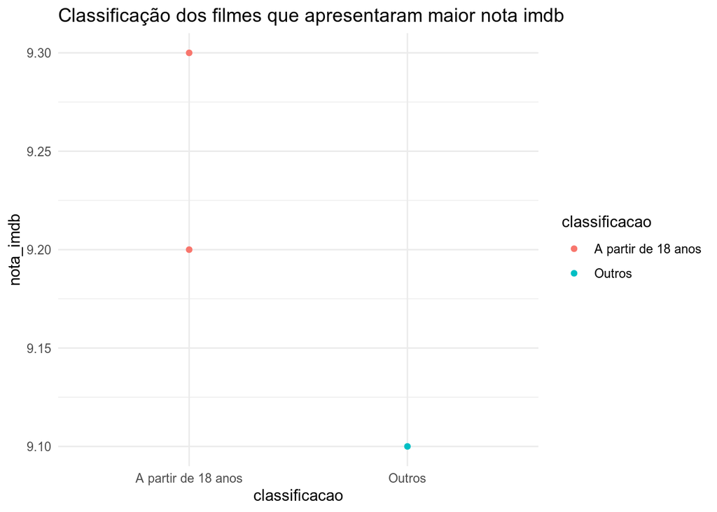

Os filmes que mais lucraram apresentaram uma faixa etaria a patir de 13 anos de idade. Enquanto que os filmes com melhores notas, apresentaram classificação a patir de 18 anos.

### Conclusão

Para produção do filme deve-se escolher ou lucro ou melhor nota_imdb, os dois não tem como.

#### Considerando Lucro:

- Diretor: James Cameron
- Gênero: Ação/Aventura/Fantasia/Ficção Cientifica
- Atores: CCH Pounder, Bryce Dallas Howard, Leonardo Dicaprio e Harrison Ford.
- Duração: Aproximadamente 175 ou 125 minutos
- Classificação etária: A partir dos 13 anos

#### Considerando melhor nota:

- Diretor: Frank Darabont
- Gênero: Crime/ Drama ou Ação
- Atores: Morgan Freeman, Al Pacino e Mathew Ziff.
- Duração: Aproximadamente 140 minutos
- Classificação etária: A partir dos 18 anos